# Homework 6, by Nikita Traynin

# Question 1

#### To test effectiveness of a new treatment for anorexia, 26 randomly selected patients were assigned to the control group with no treatment (Cont) and a separately selected random sample of 44 patients received the new treatment (CBT). Each patient was weighed two weeks prior to the start of the trial and then reweighed one month after treatment ended.

## a)

#### Is there a difference in mean Prewt between control and treatment groups at the 5% level of significance?

##### Since there are two separately selected random samples, we are doing a two-sample hypothesis test. We are checking for a difference, so the null hypothesis is that both control and treatment group Prewt are the same, while the alternative hypothesis states that Prewt is different for the two groups.

```r
data = read.table("http://www.utdallas.edu/~ammann/stat3355scripts/anorexia.txt", header = TRUE)
Test = t.test(Prewt ~ Treat, data=data)
print(Test)
```

```
    Welch Two Sample t-test

data:  Prewt by Treat
t = 0.71732, df = 43.81, p-value = 0.477
alternative hypothesis: true difference in means is not equal to 0
95 percent confidence interval:
 -1.705501  3.590117
sample estimates:
 mean in group CBT mean in group Cont
          82.50000           81.55769
```

```r
pValue = Test$p.value
```

##### Since the p-value is .477, much greater than the alpha value of .05, we cannot reject the null hypothesis and cannot say that there is a difference in means.

## b)

#### Check the normality assumption for each subset: Prewt with Cont, Prewt with FT, Postwt with Cont, Postwt with FT.

```r
data.Cont.Prewt = data[data$Treat == "Cont", "Prewt"]
data.CBT.Prewt = data[data$Treat == "CBT", "Prewt"]
data.Cont.Postwt = data[data$Treat == "Cont", "Postwt"]
data.CBT.Postwt = data[data$Treat == "CBT", "Postwt"]
par(mfrow = c(2,2))
qqnorm(data.Cont.Prewt, pch = 20, main = "Normal Q-Q Plot of Control Prewt")
qqline(data.Cont.Prewt, pch = 20)
```

```r
qqnorm(data.CBT.Prewt, pch = 20, main = "Normal Q-Q Plot of Treat. Prewt")
qqline(data.CBT.Prewt, pch = 20)
```

```r
qqnorm(data.Cont.Postwt, pch = 20, main = "Normal Q-Q Plot of Control Postwt")
qqline(data.Cont.Postwt, pch = 20)
```

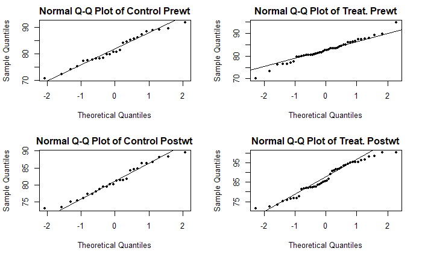

```r
qqnorm(data.CBT.Postwt, pch = 20, main = "Normal Q-Q Plot of Treat. Postwt")
qqline(data.CBT.Postwt, pch = 20)
```

## c)

#### The goal of anorexia treatment is long-term increase in weight of patients. Let WgtGain = Postwt - Prewt. Is mean weight gain for the FT group higher than mean weight gain for the Cont group at 5% level of significance?

##### Once again, we are doing a Welch Two Sample t-test. However, because we are testing for greater weight gain, it is a one-sided test this time. The Null hypothesis is that the treatment group’s weight gain is less than or equal to the control group’s weight gain. The alternative hypothesis states that the treatment group’s weight gain is greater than the control group’s.

```r
WgtGain.Cont = data.Cont.Postwt - data.Cont.Prewt
WgtGain.CBT = data.CBT.Postwt - data.CBT.Prewt
Test = t.test(WgtGain.CBT, WgtGain.Cont, alt = "greater")
print(Test)
```

```
    Welch Two Sample t-test

data:  WgtGain.CBT and WgtGain.Cont
t = 2.4539, df = 49.71, p-value = 0.008841
alternative hypothesis: true difference in means is greater than 0
95 percent confidence interval:
 1.499775      Inf
sample estimates:
mean of x mean of y
 4.281818 -0.450000
```

```r
pValue = Test$p.value
```

##### The p-value of .00884 is less than our desired .05, so we reject the null hypothesis. At this significance level, weight gain for the treatment group is higher than for the control group.

## d)

#### Construct a 95% confidence interval for mean weight gain of patients who receive the FT treatment.

```r
m = mean(WgtGain.CBT)
n = length(WgtGain.CBT)
s = sd(WgtGain.CBT)
t = qt(1-.05/2, n-1)
CI95 = m + c(-1,1)*t*(s/sqrt(n))
```

##### We can be 95% confident that the mean weight gain of patients who receive anorexia treatment lies between 2.015 and 6.549.

## e)

#### Now suppose we are interested in relative weight gain. WgtGainR = (Postwt-Prewt)/Prewt.

```r
WgtGainR.CBT = WgtGain.CBT/data.CBT.Prewt
WgtGainR.Cont = WgtGain.Cont/data.Cont.Prewt
Test = t.test(WgtGainR.CBT, WgtGainR.Cont, alt = "greater")
print(Test)
```

```
    Welch Two Sample t-test

data:  WgtGainR.CBT and WgtGainR.Cont
t = 2.1716, df = 50.398, p-value = 0.01731
alternative hypothesis: true difference in means is greater than 0
95 percent confidence interval:
 0.0121072       Inf
sample estimates:
    mean of x     mean of y
 0.0529462110 -0.0000655586
```

```r
pValue = Test$p.value
m = mean(WgtGainR.CBT)
n = length(WgtGainR.CBT)
s = sd(WgtGainR.CBT)
t = qt(1-.05/2, n-1)
CI95 = m + c(-1,1)*t*(s/sqrt(n))
```

##### Using relative weight gain instead of absolute weight gain, our p-value for part c) is now .0173, which is still below our alpha value and thus sufficient to reject the null hypothesis. For part d), the confidence interval is .0239 to .0820.

# Question 2

#### Current non-invasive methods for identification of malignant kidney tumors are imprecise and result in misidentification of non-malignant fatty tumors as malignant 33% of the time. A new method for this identification based on NMRI spectroscopy is being tested in a large clinical trial to determine if its misidentification rate is lower than current methods. Suppose a random sample of 250 patients with non-malignant kidney tumors is tested with the NMRI method and 65 were misidentified as malignant.

## a)

#### Is the misidentification rate for the new method lower than 33% at the 5% level of significance?

##### Since we are dealing with one sample being compared to a standard, we use a one-sample hypothesis test for proportions. Also, since the goal is to have a lower misidentification rate, we are doing a one-tailed t-test. The null hypothesis is that the new method has an misidentification rate of greater than or equal to .33, and the alternative hypothesis states that the new method has a lower rate of misidentification than .33.

```r
n = 250
pH = 65/250
p0 = .33
z = (pH - p0)/sqrt(p0*(1-p0)/n)
pValue = pnorm(z)
```

##### Because the p-value of .00929 is less than the desired .05, we can reject the null hypothesis.

## b)

#### Construct a 90% confidence interval for the misidentification rate of the new method.

```r
s = sqrt(pH*(1-pH)/n)
CI90 = pH + c(-1,1)*qnorm(1-.1/2)*s
```

##### We can be 90% confident that the misidentification rate of the new method lies between 21.44% and 30.56%.

## c)

#### What is the probability the null hypothesis would be rejected with a sample of size 250 if the misidentification rate in the population is 28%?

##### Since we are looking at probability of null hypothesis rejection, this is a power problem.

```r
source("http://www.utdallas.edu/~ammann/stat3355scripts/power.prop.r")
n = 250
P = .28
pH = .26
power.prop(n, P, pH, alt = "less")
```

```
[1] 0.1678282
```

##### If the misidentification rate in the population was 28%, then the probability that we would reject the null hypothesis with a sample of 250 is 16.78%

## d)

#### What sample size would be required to estimate this rate to within 0.03 of the actual value with 95% confidence if it is assumed the rate is no more than 0.30?

##### We are given a bound for the proportion. We have everything we need to find the minimum sample size.

```r
pB = .3
a = .05
z = qnorm(1-a/2)
e = .03
n = (z/e)^2*pB*(1-pB)
```

##### We would need a sample size of at least 897 to estimate the misidentification rate to within .03 of the actual value with 95% confidence.

# Question 3

## a)

#### Is there a difference in mean WellBeing at 5% level of significance between Region1 (Central and South America) and Region6 (Southeast Asia)?

##### Since we have two samples, we are using Welch’s t-test. The null hypothesis is that mean WellBeing is the same accross both Region1 and Region6. The alternative hypothesis states that mean WellBeing differs between the two regions.

```r
data = read.csv("http://www.utdallas.edu/~ammann/stat3355scripts/HappyPlanet1.csv ")
dataReg1Wb = data[data$Region == "Region1", "WellBeing"]
dataReg6Wb = data[data$Region == "Region6", "WellBeing"]
Test = t.test(dataReg1Wb, dataReg6Wb)
print(Test)
```

```
    Welch Two Sample t-test

data:  dataReg1Wb and dataReg6Wb
t = 2.5094, df = 25.859, p-value = 0.01869
alternative hypothesis: true difference in means is not equal to 0
95 percent confidence interval:
 0.1181797 1.1901536
sample estimates:
mean of x mean of y
 6.170833  5.516667
```

```r
pValue = Test$p.value
```

##### We have a p-value of .0187, which is less than the 5% significance level. We can reject the null hypothesis.

## b)

#### GDP (Gross Domestic Product) generally has a multiplicative effect, if any, which implies that a log-transformation of GDP is appropriate.

```r
colors = c("red", "orange", "yellow", "green", "blue", "purple", "brown")
par(mfrow = c(2,2))
plot(log(data$GDP), data$LifeExpectancy, pch = 20, col = data$Region, xlab = "log(GDP)", ylab = "Life Expectancy")
#legend(x="topleft", legend = levels(data$Region))
plot(log(data$GDP), data$WellBeing, pch = 20, col = data$Region, xlab = "log(GDP)", ylab = "Well Being")
```

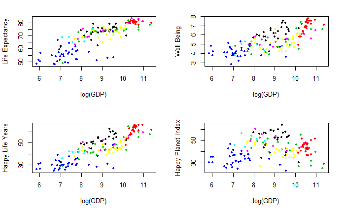

```r
#legend(x="topleft", legend = levels(data$Region), col = "red")
plot(log(data$GDP), data$HappyLifeYears, pch = 20, col = data$Region, xlab = "log(GDP)", ylab = "Happy Life Years")
#legend(x="topleft", legend = levels(data$Region))
plot(log(data$GDP), data$HappyPlanetIndex, pch = 20, col = data$Region, xlab = "log(GDP)", ylab = "Happy Planet Index")
```

```r
#legend(x="topleft", legend = levels(data$Region))
```

## c)

#### Interpret the correlation between HappyLifeYears and log(GDP).

```r
c = cor(data$HappyLifeYears, log(data$GDP))
r2 = c^2
```

##### Pearson’s R correlation between HappyLifeYears and log(GDP) is about .851. R^2 is 72.4%, which means that 72.4% of the variance in HappyLifeYears can be explained by log(GDP).

# Question 4

#### Standards for automated filling of bulk coffee bean bags require that the mean fill amount should be 10 kg and the s.d. of fill amounts should be no more than 0.01 kg. A random sample of 30 bags was weighed.

## a)

#### Use this data to determine if the mean fill amount differs from 10 at the 5% level of significance. Are the assumptions for this test reasonable?

##### This is a one-sample t-test since we are comparing a sample to a standard. The null hypothesis is that the mean fill amount is 10, while the alternative hypothesis is that the mean fill amount differs from 10.

```r
data = read.table("http://www.utdallas.edu/~ammann/stat3355scripts/CoffeeBags.txt ")
data = data$V1
n = length(data)
Test = t.test(data, mu = 10)
print(Test)
```

```
    One Sample t-test

data:  data
t = 1.7301, df = 29, p-value = 0.09425
alternative hypothesis: true mean is not equal to 10
95 percent confidence interval:
  9.998575 10.017072
sample estimates:
mean of x
 10.00782
```

```r
pValue = Test$p.value
par(mfrow = c(1,2))
plot(density(data))
qqnorm(data)
```

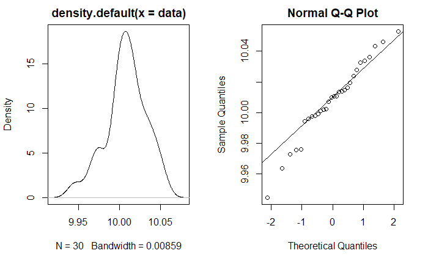

```r
qqline(data)
```

## b)

#### What is the probability this test would show a difference if the mean fill amount is 10.01, assuming that the s.d. is no more than 0.015.

##### Since we are looking for the probability of rejecting the null hypothesis, this is a power problem.

```r
Test = power.t.test(n = 30, delta = 10.01-10, sd = .015)
print(Test)
```

```
     Two-sample t test power calculation

              n = 30
          delta = 0.01
             sd = 0.015
      sig.level = 0.05
          power = 0.7187294
    alternative = two.sided

NOTE: n is number in *each* group
```

```r
power = Test$power
```

##### The probability this test would show a difference if the mean fill amount was 10.01 is 71.9%.

## c)

#### What sample size would be required to show a difference with probability 0.90 if the mean fill amount is 9.95 assuming that the s.d. is no more than 0.015.? Use 5% level of significance.

```r
Test = power.t.test(delta = 10-9.95, sd = .015, sig.level = .05, power = .90)
print(Test)
```

```
     Two-sample t test power calculation

              n = 3.22787
          delta = 0.05
             sd = 0.015
      sig.level = 0.05
          power = 0.9
    alternative = two.sided

NOTE: n is number in *each* group
```

##### We would need at least 4 bags sampled to show a difference from 9.95 mean with probability .90.

## d)

#### Construct a 95% confidence interval for the s.d. of fill amounts.

```r
a = .05
n = 30
s = sd(data)
Cl = qchisq(a/2, n-1)
Cu = qchisq(1-a/2, n-1)
CI95 = sqrt((n-1)*s^2/c(Cu, Cl))
```

##### We can be 95% confident that the standard deviation of coffee bag fill amount lies between 0.0197 to .0333.